# Torsten Issues

Author

Casey Davis

Published

January 17, 2024

# 1 Introduction

I’ve been doing some testing with the new Torsten release (v0.91.0) on an M3 Macbook Pro. I brought up an issue with M3 compatibility [here](https://discourse.mc-stan.org/t/problem-installing-torsten-0-90/27585/12). Thank you for fixing that issue. Now I’m doing some more testing, and I’m finding some issues with the Torsten solvers.

I’ve mostly done testing on my own models, but I’ve also worked on the `pk2cpt`, `pk2cpt_linode`, `pk2cpt_ode`, and `poppk2cpt` models, For the single subject models, the analytical solution didn’t work, the linear ODE solution worked, and the ODE solution didn’t work (although I’m not exactly sure why the ODE solution didn’t work. Still needs worked on, I guess.) For the population model, the analytical solution and the ODE solution worked with the model that you’ve written, but the linear ODE soolution didn’t work. So I then used the data in `poppk2cpt` and fit it with a model I’ve written, and the linear ODE and general ODE solutions worked, but the analytical solution didn’t.

# 2 Some Examples

## 2.1 Simulate from My Models

I’m starting out with simulations, mainly because it’s simpler and faster.

### 2.1.1 One-Compartment Oral with Lognormal Error

The following code simulates with Stan + Torsten with an analytical solution, linear ODE solution, and general ODE solution using code I’ve written in the past, and then also a simulation with mrgsolve as a comparison.

```r
TVCL <- 0.5
TVVC <- 12
TVKA <- 1

omega_cl <- 0
omega_vc <- 0
omega_ka <- 0

R <- diag(rep(1, times = 3))

sigma <- 0.2

dosing_data <- expand.ev(ID = 1, addl = 6, ii = 24,
                         cmt = 1, amt = 200, ss = 0, tinf = 0,
                         evid = 1) %>%
  as_tibble() %>%
  rename_all(toupper) %>%
  select(ID, TIME, everything())

times_to_simulate <- c(0.25, seq(0.5, 24*7, by = 0.5))

nonmem_data_simulate <- dosing_data %>%
  group_by(ID) %>%
  slice(rep(1, times = length(times_to_simulate))) %>%
  mutate(AMT = 0,
         ADDL = 0,
         II = 0,
         CMT = 2,
         EVID = 0,
         TIME = times_to_simulate) %>%
  ungroup() %>%
  bind_rows(dosing_data) %>%
  arrange(ID, TIME, AMT)

n_subjects <- nonmem_data_simulate %>%  # number of individuals to simulate
  distinct(ID) %>%
  count() %>%
  deframe()

n_total <- nrow(nonmem_data_simulate) # total number of time points at which to predict

subj_start <- nonmem_data_simulate %>%
  mutate(row_num = 1:n()) %>%
  group_by(ID) %>%
  slice_head(n = 1) %>%
  ungroup() %>%
  select(row_num) %>%
  deframe()

subj_end <- c(subj_start[-1] - 1, n_total)

stan_data <- list(n_subjects = n_subjects,
                  n_total = n_total,
                  time = nonmem_data_simulate$TIME,
                  amt = nonmem_data_simulate$AMT,
                  cmt = nonmem_data_simulate$CMT,
                  evid = nonmem_data_simulate$EVID,
                  rate = nonmem_data_simulate$RATE,
                  ii = nonmem_data_simulate$II,
                  addl = nonmem_data_simulate$ADDL,
                  ss = nonmem_data_simulate$SS,
                  subj_start = subj_start,
                  subj_end = subj_end,
                  TVCL = TVCL,
                  TVVC = TVVC,
                  TVKA = TVKA,
                  omega_cl = omega_cl,
                  omega_vc = omega_vc,
                  omega_ka = omega_ka,
                  R = R,
                  sigma = sigma,
                  solver = 1) # analytical = 1, mat exp = 2, rk45 = 3

model <- cmdstan_model(
  here::here("depot_1cmt_linear/Stan/Simulate/depot_1cmt_exp.stan"))

model$print()
```

```
// First Order Absorption (oral/subcutaneous)
// One-compartment PK Model
// IIV on CL, VC, KA
// exponential error - DV = IPRED*exp(eps)
// Any of analytical, matrix-exponential, or general ODE solution using Torsten

functions{

  vector depot_1cmt_ode(real t, vector y, array[] real params,
                        array[] real x_r, array[] int x_i){

    real cl = params[1];
    real vc = params[2];
    real ka = params[3];
    real ke = cl/vc;

    vector[2] dydt;

    dydt[1] = -ka*y[1];           // depot
    dydt[2] = ka*y[1] - ke*y[2];  // central

    return dydt;
  }

}
data{

  int n_subjects;
  int n_total;

  array[n_total] real amt;
  array[n_total] int cmt;
  array[n_total] int evid;
  array[n_total] real rate;
  array[n_total] real ii;
  array[n_total] int addl;
  array[n_total] int ss;
  array[n_total] real time;

  array[n_subjects] int subj_start;
```

[output cut: 115 more lines]

```

      ipred[subj_start[j]:subj_end[j]] =
                                x_ipred[subj_start[j]:subj_end[j], 2] ./ VC[j];

    }

    for(i in 1:n_total){
      if(ipred[i] == 0){
         dv[i] = 0;
      }else{
        dv[i] = lognormal_rng(log(ipred[i]), sigma);
      }
    }
  }
}
```

```r
simulated_data <- model$sample(data = stan_data,
                               fixed_param = TRUE,
                               seed = 1123,
                               iter_warmup = 0,
                               iter_sampling = 1,
                               chains = 1,
                               parallel_chains = 1)

data_analytical <- simulated_data$draws(c("dv", "ipred")) %>%
  spread_draws(dv[i], ipred[i]) %>%
  ungroup() %>%
  inner_join(nonmem_data_simulate %>%
               mutate(i = 1:n()),
             by = "i") %>%
  select(ID, AMT, II, ADDL, RATE, CMT, EVID, SS, TIME,
         DV = "dv", IPRED = "ipred") %>%
  mutate(LLOQ = 1e-6,
         BLOQ = case_when(EVID == 1 ~ NA_real_,
                          DV <= LLOQ ~ 1,
                          DV > LLOQ ~ 0,
                          TRUE ~ NA_real_),
         DV = if_else(EVID == 1 | BLOQ == 1, NA_real_, DV),
         MDV = if_else(is.na(DV), 1, 0)) %>%
  relocate(DV, .after = last_col()) %>%
  relocate(TIME, .before = DV) %>%
  mutate(solver = "analytical")


stan_data$solver <- 2
simulated_data <- model$sample(data = stan_data,
                               fixed_param = TRUE,
                               seed = 1123,
                               iter_warmup = 0,
                               iter_sampling = 1,
                               chains = 1,
                               parallel_chains = 1)

data_mat_exp <- simulated_data$draws(c("dv", "ipred")) %>%
  spread_draws(dv[i], ipred[i]) %>%
  ungroup() %>%
  inner_join(nonmem_data_simulate %>%
               mutate(i = 1:n()),
             by = "i") %>%
  select(ID, AMT, II, ADDL, RATE, CMT, EVID, SS, TIME,
         DV = "dv", IPRED = "ipred") %>%
  mutate(LLOQ = 1e-6,
         BLOQ = case_when(EVID == 1 ~ NA_real_,
                          DV <= LLOQ ~ 1,
                          DV > LLOQ ~ 0,
                          TRUE ~ NA_real_),
         DV = if_else(EVID == 1 | BLOQ == 1, NA_real_, DV),
         MDV = if_else(is.na(DV), 1, 0)) %>%
  relocate(DV, .after = last_col()) %>%
  relocate(TIME, .before = DV) %>%
  mutate(solver = "mat_exp")


stan_data$solver <- 3
simulated_data <- model$sample(data = stan_data,
                               fixed_param = TRUE,
                               seed = 1123,
                               iter_warmup = 0,
                               iter_sampling = 1,
                               chains = 1,
                               parallel_chains = 1)

data_rk45 <- simulated_data$draws(c("dv", "ipred")) %>%
  spread_draws(dv[i], ipred[i]) %>%
  ungroup() %>%
  inner_join(nonmem_data_simulate %>%
               mutate(i = 1:n()),
             by = "i") %>%
  select(ID, AMT, II, ADDL, RATE, CMT, EVID, SS, TIME,
         DV = "dv", IPRED = "ipred") %>%
  mutate(LLOQ = 1e-6,
         BLOQ = case_when(EVID == 1 ~ NA_real_,
                          DV <= LLOQ ~ 1,
                          DV > LLOQ ~ 0,
                          TRUE ~ NA_real_),
         DV = if_else(EVID == 1 | BLOQ == 1, NA_real_, DV),
         MDV = if_else(is.na(DV), 1, 0)) %>%
  relocate(DV, .after = last_col()) %>%
  relocate(TIME, .before = DV) %>%
  mutate(solver = "rk45")

## Now do it with mrgsolve to check

mod <- mread(here::here("depot_1cmt_linear/mrgsolve/depot_1cmt_exp.cpp"))

data_mrgsolve <- mod %>%
  param(tibble(CL = TVCL,
               VC = TVVC,
               KA = TVKA,
               F1 = 1,
               LAGTIME = 0)) %>%
  data_set(dosing_data) %>%
  mrgsim_df(tgrid = times_to_simulate) %>%
  as_tibble() %>%
  mutate(solver = "mrgsolve")
```

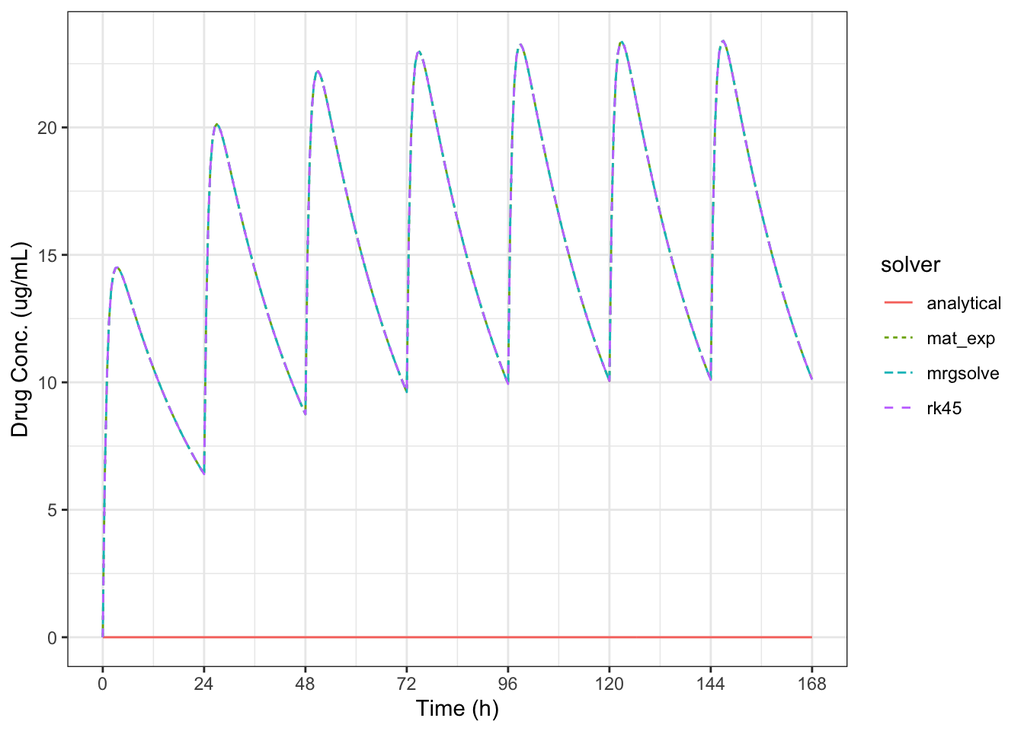

```r
mget(str_subset(ls(), "^data_")) %>%
  bind_rows() %>%
  ggplot(aes(x = TIME, y = IPRED, color = solver)) +
  geom_line(aes(linetype = solver)) +
  theme_bw() +
  scale_x_continuous(name = "Time (h)",
                     breaks = seq(0, 168, by = 24),
                     labels = seq(0, 168, by = 24)) +
  scale_y_continuous(name = "Drug Conc. (ug/mL)")
```

So you can see that the analytical solution spits out a vector of 0s, while the linear ODE, general ODE, and mrgsolve simulations are all the same.

### 2.1.2 Two-Compartment IV with Proportional Error

The following code simulates with Stan + Torsten with an analytical solution, linear ODE solution, and general ODE solution using code I’ve written in the past, and then also a simulation with mrgsolve as a comparison.

```r
TVCL <- 0.25  # L/d
TVVC <- 3     # L
TVQ <- 1      # L/d
TVVP <- 4     # L

omega_cl <- 0
omega_vc <- 0
omega_q <- 0
omega_vp <- 0

R <- diag(rep(1, times = 4))

sigma_p <- 0.2
sigma_a <- 0.05

cor_p_a <- 0

solver <- 1 # analytical = 1, mat exp = 2, rk45 = 3

# If using Torsten's analytical solver, dose into the second compartment
# (cmt = 2). If using matrix-exponential or ODE, then dose into the first
# compartment (cmt = 1)
dosing_data <- expand.ev(ID = 1, addl = 5, ii = 14,
                         cmt = 2, amt = 400, ss = 0,
                         tinf = 1/24, evid = 1) %>%
  as_tibble() %>%
  mutate(cmt = if_else(solver == 1, 2, 1)) %>%
  rename_all(toupper) %>%
  select(ID, TIME, everything())

times_to_simulate <- seq(0, 84*24, by = 1)/24

nonmem_data_simulate <- dosing_data %>%
  group_by(ID) %>%
  slice(rep(1, times = length(times_to_simulate))) %>%
  mutate(AMT = 0,
         ADDL = 0,
         II = 0,
         CMT = if_else(solver == 1, 2, 1),
         EVID = 0,
         RATE = 0,
         TIME = times_to_simulate) %>%
  ungroup() %>%
  bind_rows(dosing_data) %>%
  arrange(ID, TIME, AMT)

n_subjects <- nonmem_data_simulate %>%  # number of individuals to simulate
  distinct(ID) %>%
  count() %>%
  deframe()

n_total <- nrow(nonmem_data_simulate) # total number of time points at which to predict

subj_start <- nonmem_data_simulate %>%
  mutate(row_num = 1:n()) %>%
  group_by(ID) %>%
  slice_head(n = 1) %>%
  ungroup() %>%
  select(row_num) %>%
  deframe()

subj_end <- c(subj_start[-1] - 1, n_total)

stan_data <- list(n_subjects = n_subjects,
                  n_total = n_total,
                  time = nonmem_data_simulate$TIME,
                  amt = nonmem_data_simulate$AMT,
                  cmt = nonmem_data_simulate$CMT,
                  evid = nonmem_data_simulate$EVID,
                  rate = nonmem_data_simulate$RATE,
                  ii = nonmem_data_simulate$II,
                  addl = nonmem_data_simulate$ADDL,
                  ss = nonmem_data_simulate$SS,
                  subj_start = subj_start,
                  subj_end = subj_end,
                  TVCL = TVCL,
                  TVVC = TVVC,
                  TVQ = TVQ,
                  TVVP = TVVP,
                  omega_cl = omega_cl,
                  omega_vc = omega_vc,
                  omega_q = omega_q,
                  omega_vp = omega_vp,
                  R = R,
                  sigma_p = sigma_p,
                  sigma_a = sigma_a,
                  cor_p_a = cor_p_a,
                  solver = solver) # analytical = 1, mat exp = 2, rk45 = 3

model <- cmdstan_model(
  here::here("iv_2cmt_linear/Stan/Simulate/iv_2cmt_ppa.stan"))

model$print()
```

```
// IV infusion
// Two-compartment PK Model
// IIV on CL, VC, Q, and VP (full covariance matrix)
// proportional plus additive error - DV = IPRED*(1 + eps_p) + eps_a
// Any of analytical, matrix-exponential, or general ODE solution using Torsten
// Observations are generated from a normal that is truncated below at 0
// Since we have a normal distribution on the error, but the DV must be > 0, it
//   generates values from a normal that is truncated below at 0

functions{

  real normal_lb_rng(real mu, real sigma, real lb){

    real p_lb = normal_cdf(lb | mu, sigma);
    real u = uniform_rng(p_lb, 1);
    real y = mu + sigma * inv_Phi(u);
    return y;

  }

  vector iv_2cmt_ode(real t, vector y, array[] real params,
                     array[] real x_r, array[] int x_i){

    real cl = params[1];
    real vc = params[2];
    real q = params[3];
    real vp = params[4];

    real ke = cl/vc;
    real k_cp = q/vc;
    real k_pc = q/vp;

    vector[2] dydt;

    dydt[1] = -(ke + k_cp)*y[1] + k_pc*y[2];  // central
    dydt[2] = k_cp*y[1] - k_pc*y[2];          // peripheral

    return dydt;
  }

```

[output cut: 153 more lines]

```
    }

    for(i in 1:n_total){
      if(ipred[i] == 0){
         dv[i] = 0;
      }else{
        real ipred_tmp = ipred[i];
        real sigma_tmp = sqrt(square(ipred_tmp) * Sigma[1, 1] + Sigma[2, 2] +
                              2*ipred_tmp*Sigma[2, 1]);
        dv[i] = normal_lb_rng(ipred_tmp, sigma_tmp, 0.0);

      }
    }
  }
}
```

```r
simulated_data <- model$sample(data = stan_data,
                               fixed_param = TRUE,
                               seed = 112358,
                               iter_warmup = 0,
                               iter_sampling = 1,
                               chains = 1,
                               parallel_chains = 1)

data_analytical <- simulated_data$draws(c("dv", "ipred")) %>%
  spread_draws(dv[i], ipred[i]) %>%
  ungroup() %>%
  inner_join(nonmem_data_simulate %>%
               mutate(i = 1:n()),
             by = "i") %>%
  select(ID, AMT, II, ADDL, RATE, CMT, EVID, SS, TIME,
         DV = "dv", IPRED = "ipred") %>%
  mutate(LLOQ = 1e-6,
         BLOQ = case_when(EVID == 1 ~ NA_real_,
                          DV <= LLOQ ~ 1,
                          DV > LLOQ ~ 0,
                          TRUE ~ NA_real_),
         DV = if_else(EVID == 1 | BLOQ == 1, NA_real_, DV),
         MDV = if_else(is.na(DV), 1, 0)) %>%
  relocate(DV, .after = last_col()) %>%
  relocate(TIME, .before = DV) %>%
  mutate(solver = "analytical")


solver <- 2
dosing_data <- dosing_data %>%
  mutate(CMT = if_else(solver == 1, 2, 1))

nonmem_data_simulate <- dosing_data %>%
  group_by(ID) %>%
  slice(rep(1, times = length(times_to_simulate))) %>%
  mutate(AMT = 0,
         ADDL = 0,
         II = 0,
         CMT = if_else(solver == 1, 2, 1),
         EVID = 0,
         RATE = 0,
         TIME = times_to_simulate) %>%
  ungroup() %>%
  bind_rows(dosing_data) %>%
  arrange(ID, TIME, AMT)

stan_data <- list(n_subjects = n_subjects,
                  n_total = n_total,
                  time = nonmem_data_simulate$TIME,
                  amt = nonmem_data_simulate$AMT,
                  cmt = nonmem_data_simulate$CMT,
                  evid = nonmem_data_simulate$EVID,
                  rate = nonmem_data_simulate$RATE,
                  ii = nonmem_data_simulate$II,
                  addl = nonmem_data_simulate$ADDL,
                  ss = nonmem_data_simulate$SS,
                  subj_start = subj_start,
                  subj_end = subj_end,
                  TVCL = TVCL,
                  TVVC = TVVC,
                  TVQ = TVQ,
                  TVVP = TVVP,
                  omega_cl = omega_cl,
                  omega_vc = omega_vc,
                  omega_q = omega_q,
                  omega_vp = omega_vp,
                  R = R,
                  sigma_p = sigma_p,
                  sigma_a = sigma_a,
                  cor_p_a = cor_p_a,
                  solver = solver)

simulated_data <- model$sample(data = stan_data,
                               fixed_param = TRUE,
                               seed = 112358,
                               iter_warmup = 0,
                               iter_sampling = 1,
                               chains = 1,
                               parallel_chains = 1)

data_mat_exp <- simulated_data$draws(c("dv", "ipred")) %>%
  spread_draws(dv[i], ipred[i]) %>%
  ungroup() %>%
  inner_join(nonmem_data_simulate %>%
               mutate(i = 1:n()),
             by = "i") %>%
  select(ID, AMT, II, ADDL, RATE, CMT, EVID, SS, TIME,
         DV = "dv", IPRED = "ipred") %>%
  mutate(LLOQ = 1e-6,
         BLOQ = case_when(EVID == 1 ~ NA_real_,
                          DV <= LLOQ ~ 1,
                          DV > LLOQ ~ 0,
                          TRUE ~ NA_real_),
         DV = if_else(EVID == 1 | BLOQ == 1, NA_real_, DV),
         MDV = if_else(is.na(DV), 1, 0)) %>%
  relocate(DV, .after = last_col()) %>%
  relocate(TIME, .before = DV) %>%
  mutate(solver = "mat_exp")




solver <- 3
stan_data$solver <- solver

simulated_data <- model$sample(data = stan_data,
                               fixed_param = TRUE,
                               seed = 112358,
                               iter_warmup = 0,
                               iter_sampling = 1,
                               chains = 1,
                               parallel_chains = 1)

data_rk45 <- simulated_data$draws(c("dv", "ipred")) %>%
  spread_draws(dv[i], ipred[i]) %>%
  ungroup() %>%
  inner_join(nonmem_data_simulate %>%
               mutate(i = 1:n()),
             by = "i") %>%
  select(ID, AMT, II, ADDL, RATE, CMT, EVID, SS, TIME,
         DV = "dv", IPRED = "ipred") %>%
  mutate(LLOQ = 1e-6,
         BLOQ = case_when(EVID == 1 ~ NA_real_,
                          DV <= LLOQ ~ 1,
                          DV > LLOQ ~ 0,
                          TRUE ~ NA_real_),
         DV = if_else(EVID == 1 | BLOQ == 1, NA_real_, DV),
         MDV = if_else(is.na(DV), 1, 0)) %>%
  relocate(DV, .after = last_col()) %>%
  relocate(TIME, .before = DV) %>%
  mutate(solver = "rk45")


## Now do it with mrgsolve to check

mod <- mread(here::here("iv_2cmt_linear/mrgsolve/iv_2cmt_ppa.cpp"))

data_mrgsolve <- mod %>%
  param(tibble(TVCL = TVCL,
               TVVC = TVVC,
               TVQ = TVQ,
               TVVP = TVVP)) %>%
  data_set(dosing_data) %>%
  mrgsim_df(tgrid = times_to_simulate) %>%
  as_tibble() %>%
  mutate(solver = "mrgsolve")
```

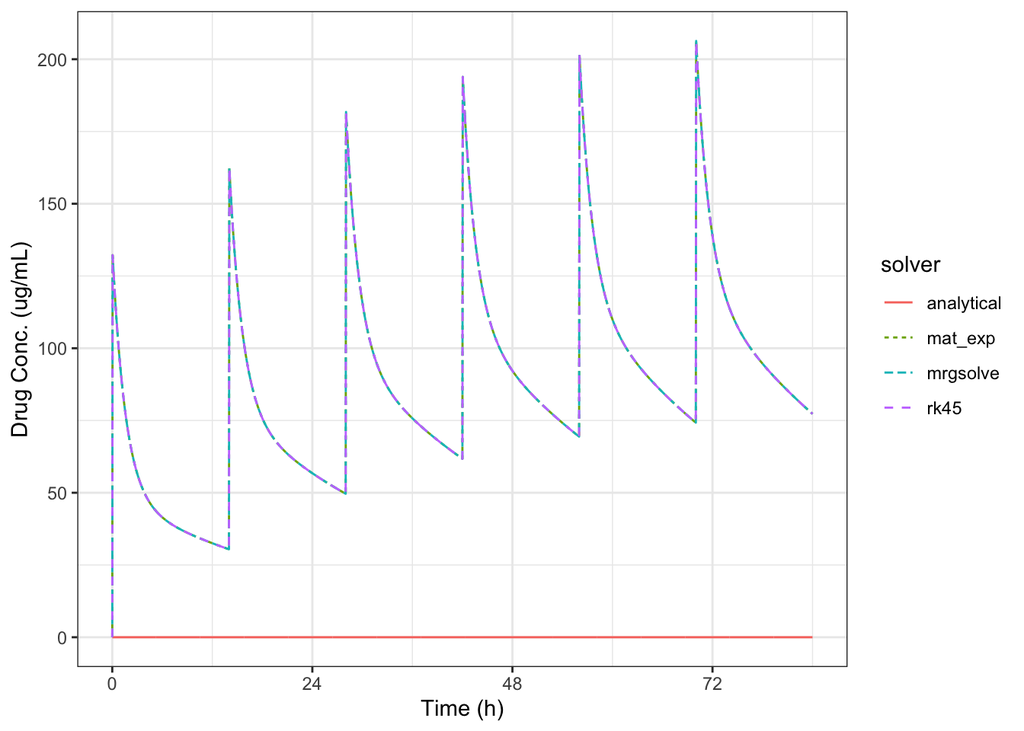

```r
mget(str_subset(ls(), "^data_")) %>%
  bind_rows() %>%
  ggplot(aes(x = TIME, y = IPRED, color = solver)) +
  geom_line(aes(linetype = solver)) +
  theme_bw() +
  scale_x_continuous(name = "Time (h)",
                     breaks = seq(0, 168, by = 24),
                     labels = seq(0, 168, by = 24)) +
  scale_y_continuous(name = "Drug Conc. (ug/mL)")
```

So you can see that the analytical solution spits out a vector of 0s, while the linear ODE, general ODE, and mrgsolve simulations are all the same.

## 2.2 Fitting `pk2cpt`, `pk2cpt_linode`, `pk2cpt_ode` from `example-models/`

I made a few modifications in the R script to fit the project and a couple small changes in the general ODE model while trying to debug it, but no changes of any major substance.

### 2.2.1 `pk2cpt`

```r
model_analytical <- cmdstan_model(
  here::here("example_models_metrum/pk2cpt/pk2cpt.stan"))

fit_analytical <- model_analytical$sample(
  data = here::here("example_models_metrum/pk2cpt/pk2cpt.data.R"),
  init = here::here("example_models_metrum/pk2cpt/pk2cpt.init.R"),
  seed = 3191951,
  chains = 1,
  parallel_chains = 1,
  iter_warmup = 500,
  iter_sampling = 1000,
  adapt_delta = 0.80)
```

```
Running MCMC with 1 chain...
```

```
Chain 1 Rejecting initial value:
```

```
Chain 1   Error evaluating the log probability at the initial value.
```

```
Chain 1 Exception: normal_lpdf: Location parameter[1] is -inf, but must be finite! (in '/var/folders/cq/ymsm1rv904b6mwygsq0z0z4w0000gn/T/Rtmpf4WYqS/model-27d828384b8b.stan', line 66, column 2 to column 40)
Chain 1 Exception: normal_lpdf: Location parameter[1] is -inf, but must be finite! (in '/var/folders/cq/ymsm1rv904b6mwygsq0z0z4w0000gn/T/Rtmpf4WYqS/model-27d828384b8b.stan', line 66, column 2 to column 40)
```

[output not shown]

[output not shown]

[output not shown]

[output not shown]

[output not shown]

[output not shown]

```
Chain 1 Initialization between (-2, 2) failed after 1 attempts.
```

```
Chain 1  Try specifying initial values, reducing ranges of constrained values, or reparameterizing the model.
```

```
Chain 1 Initialization failed.
```

In particular, `Chain 1 Exception: normal_lpdf: Location parameter[1] is -inf, but must be finite!` implies that the prediction is 0.

### 2.2.2 `pk2cpt_linode`

```r
model_mat_exp <- cmdstan_model(
  here::here("example_models_metrum/pk2cpt_linode/pk2cpt_linode.stan"))

fit_mat_exp <- model_mat_exp$sample(
  data = here::here("example_models_metrum/pk2cpt_linode/pk2cpt_linode.data.R"),
  init = here::here("example_models_metrum/pk2cpt_linode/pk2cpt_linode.init.R"),
  seed = 3191951,
  chains = 4,
  parallel_chains = 4,
  iter_warmup = 500,
  iter_sampling = 1000,
  refresh = 0,
  adapt_delta = 0.80)
```

```
Running MCMC with 4 parallel chains...
```

[output not shown]

[output not shown]

[output not shown]

[output not shown]

[output not shown]

[output not shown]

```
Chain 1 Informational Message: The current Metropolis proposal is about to be rejected because of the following issue:
```

```
Chain 1 Exception: normal_lpdf: Location parameter[1] is -inf, but must be finite! (in '/var/folders/cq/ymsm1rv904b6mwygsq0z0z4w0000gn/T/Rtmpf4WYqS/model-27d87e0330a8.stan', line 80, column 2 to column 40)
```

```
Chain 1 If this warning occurs sporadically, such as for highly constrained variable types like covariance matrices, then the sampler is fine,
```

```
Chain 1 but if this warning occurs often then your model may be either severely ill-conditioned or misspecified.
```

```
Chain 1
```

[output not shown]

[output not shown]

[output not shown]

[output not shown]

[output not shown]

[output not shown]

```
Chain 2 Informational Message: The current Metropolis proposal is about to be rejected because of the following issue:
```

```
Chain 2 Exception: pk2cpt_linode_model_namespace::log_prob: cHat[1] is nan, but must be greater than or equal to 0.000000 (in '/var/folders/cq/ymsm1rv904b6mwygsq0z0z4w0000gn/T/Rtmpf4WYqS/model-27d87e0330a8.stan', line 49, column 2 to column 33)
```

```
Chain 2 If this warning occurs sporadically, such as for highly constrained variable types like covariance matrices, then the sampler is fine,
```

```
Chain 2 but if this warning occurs often then your model may be either severely ill-conditioned or misspecified.
```

```
Chain 2
```

```
Chain 2 Informational Message: The current Metropolis proposal is about to be rejected because of the following issue:
```

```
Chain 2 Exception: normal_lpdf: Location parameter[1] is -inf, but must be finite! (in '/var/folders/cq/ymsm1rv904b6mwygsq0z0z4w0000gn/T/Rtmpf4WYqS/model-27d87e0330a8.stan', line 80, column 2 to column 40)
```

```
Chain 2 If this warning occurs sporadically, such as for highly constrained variable types like covariance matrices, then the sampler is fine,
```

```
Chain 2 but if this warning occurs often then your model may be either severely ill-conditioned or misspecified.
```

```
Chain 2
```

[output not shown]

[output not shown]

[output not shown]

[output not shown]

[output not shown]

[output not shown]

```
Chain 3 Informational Message: The current Metropolis proposal is about to be rejected because of the following issue:
```

```
Chain 3 Exception: pk2cpt_linode_model_namespace::log_prob: cHat[1] is nan, but must be greater than or equal to 0.000000 (in '/var/folders/cq/ymsm1rv904b6mwygsq0z0z4w0000gn/T/Rtmpf4WYqS/model-27d87e0330a8.stan', line 49, column 2 to column 33)
```

```
Chain 3 If this warning occurs sporadically, such as for highly constrained variable types like covariance matrices, then the sampler is fine,
```

```
Chain 3 but if this warning occurs often then your model may be either severely ill-conditioned or misspecified.
```

```
Chain 3
```

```
Chain 3 Informational Message: The current Metropolis proposal is about to be rejected because of the following issue:
```

```
Chain 3 Exception: normal_lpdf: Location parameter[1] is -inf, but must be finite! (in '/var/folders/cq/ymsm1rv904b6mwygsq0z0z4w0000gn/T/Rtmpf4WYqS/model-27d87e0330a8.stan', line 80, column 2 to column 40)
```

```
Chain 3 If this warning occurs sporadically, such as for highly constrained variable types like covariance matrices, then the sampler is fine,
```

```
Chain 3 but if this warning occurs often then your model may be either severely ill-conditioned or misspecified.
```

```
Chain 3
```

[output not shown]

[output not shown]

[output not shown]

[output not shown]

[output not shown]

[output not shown]

```
Chain 4 Informational Message: The current Metropolis proposal is about to be rejected because of the following issue:
```

```
Chain 4 Exception: pk2cpt_linode_model_namespace::log_prob: cHat[1] is nan, but must be greater than or equal to 0.000000 (in '/var/folders/cq/ymsm1rv904b6mwygsq0z0z4w0000gn/T/Rtmpf4WYqS/model-27d87e0330a8.stan', line 49, column 2 to column 33)
```

```
Chain 4 If this warning occurs sporadically, such as for highly constrained variable types like covariance matrices, then the sampler is fine,
```

```
Chain 4 but if this warning occurs often then your model may be either severely ill-conditioned or misspecified.
```

```
Chain 4
```

```
Chain 4 finished in 7.2 seconds.
Chain 2 finished in 7.8 seconds.
Chain 3 finished in 8.4 seconds.
Chain 1 finished in 8.9 seconds.

All 4 chains finished successfully.
Mean chain execution time: 8.1 seconds.
Total execution time: 9.1 seconds.
```

Works fine. I also fit the `pk2cpt` and `pk2cpt_ode` data with this model with no issues.

### 2.2.3 `pk2cpt_ode`

```r
model_rk45 <- cmdstan_model(
  here::here("example_models_metrum/pk2cpt_ode/pk2cpt_ode.stan"))

stan_data_rk45 <- rstan::read_rdump(
  here::here("example_models_metrum/pk2cpt_ode/pk2cpt_ode.data.R"))

stan_data_rk45$prior_only <- 1

fit_rk45 <- model_rk45$sample(
  data = stan_data_rk45,
  init = here::here("example_models_metrum/pk2cpt_ode/pk2cpt_ode.init.R"),
  seed = 3191951,
  chains = 1,
  parallel_chains = 1,
  iter_warmup = 1,
  iter_sampling = 1,
  adapt_delta = 0.80)
```

```
Running MCMC with 1 chain...

Chain 1 [[0,0,0,0,0,0,0,0,0,0,0,0,0,0,0,0,0,0,0,0,0],[0,0,0,0,0,0,0,0,0,0,0,0,0,0,0,0,0,0,0,0,0],[0,0,0,0,0,0,0,0,0,0,0,0,0,0,0,0,0,0,0,0,0]]
Chain 1 [[0,0,0,0,0,0,0,0,0,0,0,0,0,0,0,0,0,0,0,0,0],[0,0,0,0,0,0,0,0,0,0,0,0,0,0,0,0,0,0,0,0,0],[0,0,0,0,0,0,0,0,0,0,0,0,0,0,0,0,0,0,0,0,0]]
Chain 1 WARNING: No variance estimation is
Chain 1          performed for num_warmup < 20
Chain 1 [[0,0,0,0,0,0,0,0,0,0,0,0,0,0,0,0,0,0,0,0,0],[0,0,0,0,0,0,0,0,0,0,0,0,0,0,0,0,0,0,0,0,0],[0,0,0,0,0,0,0,0,0,0,0,0,0,0,0,0,0,0,0,0,0]]
Chain 1 [[0,0,0,0,0,0,0,0,0,0,0,0,0,0,0,0,0,0,0,0,0],[0,0,0,0,0,0,0,0,0,0,0,0,0,0,0,0,0,0,0,0,0],[0,0,0,0,0,0,0,0,0,0,0,0,0,0,0,0,0,0,0,0,0]]
Chain 1 [[0,0,0,0,0,0,0,0,0,0,0,0,0,0,0,0,0,0,0,0,0],[0,0,0,0,0,0,0,0,0,0,0,0,0,0,0,0,0,0,0,0,0],[0,0,0,0,0,0,0,0,0,0,0,0,0,0,0,0,0,0,0,0,0]]
Chain 1 [[0,0,0,0,0,0,0,0,0,0,0,0,0,0,0,0,0,0,0,0,0],[0,0,0,0,0,0,0,0,0,0,0,0,0,0,0,0,0,0,0,0,0],[0,0,0,0,0,0,0,0,0,0,0,0,0,0,0,0,0,0,0,0,0]]
Chain 1 [[0,0,0,0,0,0,0,0,0,0,0,0,0,0,0,0,0,0,0,0,0],[0,0,0,0,0,0,0,0,0,0,0,0,0,0,0,0,0,0,0,0,0],[0,0,0,0,0,0,0,0,0,0,0,0,0,0,0,0,0,0,0,0,0]]
Chain 1 [[0,0,0,0,0,0,0,0,0,0,0,0,0,0,0,0,0,0,0,0,0],[0,0,0,0,0,0,0,0,0,0,0,0,0,0,0,0,0,0,0,0,0],[0,0,0,0,0,0,0,0,0,0,0,0,0,0,0,0,0,0,0,0,0]]
Chain 1 [[0,0,0,0,0,0,0,0,0,0,0,0,0,0,0,0,0,0,0,0,0],[0,0,0,0,0,0,0,0,0,0,0,0,0,0,0,0,0,0,0,0,0],[0,0,0,0,0,0,0,0,0,0,0,0,0,0,0,0,0,0,0,0,0]]
Chain 1 [[0,0,0,0,0,0,0,0,0,0,0,0,0,0,0,0,0,0,0,0,0],[0,0,0,0,0,0,0,0,0,0,0,0,0,0,0,0,0,0,0,0,0],[0,0,0,0,0,0,0,0,0,0,0,0,0,0,0,0,0,0,0,0,0]]
Chain 1 Iteration: 1 / 2 [ 50%]  (Warmup)
Chain 1 [[0,0,0,0,0,0,0,0,0,0,0,0,0,0,0,0,0,0,0,0,0],[0,0,0,0,0,0,0,0,0,0,0,0,0,0,0,0,0,0,0,0,0],[0,0,0,0,0,0,0,0,0,0,0,0,0,0,0,0,0,0,0,0,0]]
Chain 1 [[0,0,0,0,0,0,0,0,0,0,0,0,0,0,0,0,0,0,0,0,0],[0,0,0,0,0,0,0,0,0,0,0,0,0,0,0,0,0,0,0,0,0],[0,0,0,0,0,0,0,0,0,0,0,0,0,0,0,0,0,0,0,0,0]]
Chain 1 [[0,0,0,0,0,0,0,0,0,0,0,0,0,0,0,0,0,0,0,0,0],[0,0,0,0,0,0,0,0,0,0,0,0,0,0,0,0,0,0,0,0,0],[0,0,0,0,0,0,0,0,0,0,0,0,0,0,0,0,0,0,0,0,0]]
Chain 1 [[0,0,0,0,0,0,0,0,0,0,0,0,0,0,0,0,0,0,0,0,0],[0,0,0,0,0,0,0,0,0,0,0,0,0,0,0,0,0,0,0,0,0],[0,0,0,0,0,0,0,0,0,0,0,0,0,0,0,0,0,0,0,0,0]]
Chain 1 [[0,0,0,0,0,0,0,0,0,0,0,0,0,0,0,0,0,0,0,0,0],[0,0,0,0,0,0,0,0,0,0,0,0,0,0,0,0,0,0,0,0,0],[0,0,0,0,0,0,0,0,0,0,0,0,0,0,0,0,0,0,0,0,0]]
Chain 1 [[0,0,0,0,0,0,0,0,0,0,0,0,0,0,0,0,0,0,0,0,0],[0,0,0,0,0,0,0,0,0,0,0,0,0,0,0,0,0,0,0,0,0],[0,0,0,0,0,0,0,0,0,0,0,0,0,0,0,0,0,0,0,0,0]]
Chain 1 [[0,0,0,0,0,0,0,0,0,0,0,0,0,0,0,0,0,0,0,0,0],[0,0,0,0,0,0,0,0,0,0,0,0,0,0,0,0,0,0,0,0,0],[0,0,0,0,0,0,0,0,0,0,0,0,0,0,0,0,0,0,0,0,0]]
Chain 1 [[0,0,0,0,0,0,0,0,0,0,0,0,0,0,0,0,0,0,0,0,0],[0,0,0,0,0,0,0,0,0,0,0,0,0,0,0,0,0,0,0,0,0],[0,0,0,0,0,0,0,0,0,0,0,0,0,0,0,0,0,0,0,0,0]]
Chain 1 [[0,0,0,0,0,0,0,0,0,0,0,0,0,0,0,0,0,0,0,0,0],[0,0,0,0,0,0,0,0,0,0,0,0,0,0,0,0,0,0,0,0,0],[0,0,0,0,0,0,0,0,0,0,0,0,0,0,0,0,0,0,0,0,0]]
Chain 1 [[0,0,0,0,0,0,0,0,0,0,0,0,0,0,0,0,0,0,0,0,0],[0,0,0,0,0,0,0,0,0,0,0,0,0,0,0,0,0,0,0,0,0],[0,0,0,0,0,0,0,0,0,0,0,0,0,0,0,0,0,0,0,0,0]]
Chain 1 [[0,0,0,0,0,0,0,0,0,0,0,0,0,0,0,0,0,0,0,0,0],[0,0,0,0,0,0,0,0,0,0,0,0,0,0,0,0,0,0,0,0,0],[0,0,0,0,0,0,0,0,0,0,0,0,0,0,0,0,0,0,0,0,0]]
Chain 1 [[0,0,0,0,0,0,0,0,0,0,0,0,0,0,0,0,0,0,0,0,0],[0,0,0,0,0,0,0,0,0,0,0,0,0,0,0,0,0,0,0,0,0],[0,0,0,0,0,0,0,0,0,0,0,0,0,0,0,0,0,0,0,0,0]]
Chain 1 [[0,0,0,0,0,0,0,0,0,0,0,0,0,0,0,0,0,0,0,0,0],[0,0,0,0,0,0,0,0,0,0,0,0,0,0,0,0,0,0,0,0,0],[0,0,0,0,0,0,0,0,0,0,0,0,0,0,0,0,0,0,0,0,0]]
Chain 1 [[0,0,0,0,0,0,0,0,0,0,0,0,0,0,0,0,0,0,0,0,0],[0,0,0,0,0,0,0,0,0,0,0,0,0,0,0,0,0,0,0,0,0],[0,0,0,0,0,0,0,0,0,0,0,0,0,0,0,0,0,0,0,0,0]]
Chain 1 [[0,0,0,0,0,0,0,0,0,0,0,0,0,0,0,0,0,0,0,0,0],[0,0,0,0,0,0,0,0,0,0,0,0,0,0,0,0,0,0,0,0,0],[0,0,0,0,0,0,0,0,0,0,0,0,0,0,0,0,0,0,0,0,0]]
Chain 1 [[0,0,0,0,0,0,0,0,0,0,0,0,0,0,0,0,0,0,0,0,0],[0,0,0,0,0,0,0,0,0,0,0,0,0,0,0,0,0,0,0,0,0],[0,0,0,0,0,0,0,0,0,0,0,0,0,0,0,0,0,0,0,0,0]]
Chain 1 Iteration: 2 / 2 [100%]  (Sampling)
```

```
Chain 1 Exception: normal_rng: Location parameter is -inf, but must be finite! (in '/var/folders/cq/ymsm1rv904b6mwygsq0z0z4w0000gn/T/Rtmpf4WYqS/model-27d874055d46.stan', line 101, column 6 to column 60)
```

[output not shown]

[output not shown]

[output not shown]

```
Chain 1 finished in 0.0 seconds.
```

As you can see, it’s returning a vector of 0s as the solution.

## 2.3 Fitting `poppk2cpt` from `example-models/`

I made a couple adjustments in `poppk2cpt.stan` so that it can be fit with an analytical solver, the linear ODE, or the general ODE.

### 2.3.1 Analytical Solution

```r
model <- cmdstan_model(
  here::here("example_models_metrum/poppk2cpt/poppk2cpt.stan"))

stan_data <- rstan::read_rdump(
  here::here("example_models_metrum/poppk2cpt/poppk2cpt.data.R"))

stan_data$solver <- 1

fit_analytical <- model$sample(
  data = stan_data,
  init = here::here("example_models_metrum/poppk2cpt/poppk2cpt.init.R"),
  seed = 3191951,
  chains = 4,
  parallel_chains = 4,
  iter_warmup = 500,
  iter_sampling = 500,
  adapt_delta = 0.80)
```

```
Running MCMC with 4 parallel chains...

Chain 1 Iteration:   1 / 1000 [  0%]  (Warmup)
```

[output not shown]

[output not shown]

[output not shown]

```
Chain 1 Informational Message: The current Metropolis proposal is about to be rejected because of the following issue:
```

```
Chain 1 Exception: poppk2cpt_model_namespace::log_prob: x[1, 1] is nan, but must be greater than or equal to 0.000000 (in '/var/folders/cq/ymsm1rv904b6mwygsq0z0z4w0000gn/T/Rtmpf4WYqS/model-27d8562ebc6f.stan', line 83, column 2 to column 32)
```

```
Chain 1 If this warning occurs sporadically, such as for highly constrained variable types like covariance matrices, then the sampler is fine,
```

```
Chain 1 but if this warning occurs often then your model may be either severely ill-conditioned or misspecified.
```

```
Chain 1
```

```
Chain 1 Informational Message: The current Metropolis proposal is about to be rejected because of the following issue:
```

```
Chain 1 Exception: poppk2cpt_model_namespace::log_prob: x[1, 1] is nan, but must be greater than or equal to 0.000000 (in '/var/folders/cq/ymsm1rv904b6mwygsq0z0z4w0000gn/T/Rtmpf4WYqS/model-27d8562ebc6f.stan', line 83, column 2 to column 32)
```

```
Chain 1 If this warning occurs sporadically, such as for highly constrained variable types like covariance matrices, then the sampler is fine,
```

```
Chain 1 but if this warning occurs often then your model may be either severely ill-conditioned or misspecified.
```

```
Chain 1
```

```
Chain 1 Informational Message: The current Metropolis proposal is about to be rejected because of the following issue:
```

```
Chain 1 Exception: PMXTwoCptModel: CL is 0, but must be positive finite! (in '/var/folders/cq/ymsm1rv904b6mwygsq0z0z4w0000gn/T/Rtmpf4WYqS/model-27d8562ebc6f.stan', line 106, column 6 to line 114, column 67)
```

```
Chain 1 If this warning occurs sporadically, such as for highly constrained variable types like covariance matrices, then the sampler is fine,
```

```
Chain 1 but if this warning occurs often then your model may be either severely ill-conditioned or misspecified.
```

```
Chain 1
```

```
Chain 1 Informational Message: The current Metropolis proposal is about to be rejected because of the following issue:
```

```
Chain 1 Exception: poppk2cpt_model_namespace::log_prob: x[1, 1] is nan, but must be greater than or equal to 0.000000 (in '/var/folders/cq/ymsm1rv904b6mwygsq0z0z4w0000gn/T/Rtmpf4WYqS/model-27d8562ebc6f.stan', line 83, column 2 to column 32)
```

```
Chain 1 If this warning occurs sporadically, such as for highly constrained variable types like covariance matrices, then the sampler is fine,
```

```
Chain 1 but if this warning occurs often then your model may be either severely ill-conditioned or misspecified.
```

```
Chain 1
```

```
Chain 2 Iteration:   1 / 1000 [  0%]  (Warmup)
```

[output not shown]

[output not shown]

[output not shown]

```
Chain 2 Informational Message: The current Metropolis proposal is about to be rejected because of the following issue:
```

```
Chain 2 Exception: poppk2cpt_model_namespace::log_prob: x[1, 1] is nan, but must be greater than or equal to 0.000000 (in '/var/folders/cq/ymsm1rv904b6mwygsq0z0z4w0000gn/T/Rtmpf4WYqS/model-27d8562ebc6f.stan', line 83, column 2 to column 32)
```

```
Chain 2 If this warning occurs sporadically, such as for highly constrained variable types like covariance matrices, then the sampler is fine,
```

```
Chain 2 but if this warning occurs often then your model may be either severely ill-conditioned or misspecified.
```

```
Chain 2
```

```
Chain 2 Informational Message: The current Metropolis proposal is about to be rejected because of the following issue:
```

```
Chain 2 Exception: poppk2cpt_model_namespace::log_prob: x[1, 1] is nan, but must be greater than or equal to 0.000000 (in '/var/folders/cq/ymsm1rv904b6mwygsq0z0z4w0000gn/T/Rtmpf4WYqS/model-27d8562ebc6f.stan', line 83, column 2 to column 32)
```

```
Chain 2 If this warning occurs sporadically, such as for highly constrained variable types like covariance matrices, then the sampler is fine,
```

```
Chain 2 but if this warning occurs often then your model may be either severely ill-conditioned or misspecified.
```

```
Chain 2
```

```
Chain 2 Informational Message: The current Metropolis proposal is about to be rejected because of the following issue:
```

```
Chain 2 Exception: PMXTwoCptModel: Q is 0, but must be positive finite! (in '/var/folders/cq/ymsm1rv904b6mwygsq0z0z4w0000gn/T/Rtmpf4WYqS/model-27d8562ebc6f.stan', line 106, column 6 to line 114, column 67)
```

```
Chain 2 If this warning occurs sporadically, such as for highly constrained variable types like covariance matrices, then the sampler is fine,
```

```
Chain 2 but if this warning occurs often then your model may be either severely ill-conditioned or misspecified.
```

```
Chain 2
```

```
Chain 2 Informational Message: The current Metropolis proposal is about to be rejected because of the following issue:
```

```
Chain 2 Exception: poppk2cpt_model_namespace::log_prob: x[3, 273] is -3.79823e-65, but must be greater than or equal to 0.000000 (in '/var/folders/cq/ymsm1rv904b6mwygsq0z0z4w0000gn/T/Rtmpf4WYqS/model-27d8562ebc6f.stan', line 83, column 2 to column 32)
```

```
Chain 2 If this warning occurs sporadically, such as for highly constrained variable types like covariance matrices, then the sampler is fine,
```

```
Chain 2 but if this warning occurs often then your model may be either severely ill-conditioned or misspecified.
```

```
Chain 2
```

```
Chain 3 Iteration:   1 / 1000 [  0%]  (Warmup)
```

[output not shown]

[output not shown]

[output not shown]

```
Chain 3 Informational Message: The current Metropolis proposal is about to be rejected because of the following issue:
```

```
Chain 3 Exception: poppk2cpt_model_namespace::log_prob: x[1, 1] is nan, but must be greater than or equal to 0.000000 (in '/var/folders/cq/ymsm1rv904b6mwygsq0z0z4w0000gn/T/Rtmpf4WYqS/model-27d8562ebc6f.stan', line 83, column 2 to column 32)
```

```
Chain 3 If this warning occurs sporadically, such as for highly constrained variable types like covariance matrices, then the sampler is fine,
```

```
Chain 3 but if this warning occurs often then your model may be either severely ill-conditioned or misspecified.
```

```
Chain 3
```

```
Chain 3 Informational Message: The current Metropolis proposal is about to be rejected because of the following issue:
```

```
Chain 3 Exception: poppk2cpt_model_namespace::log_prob: x[1, 1] is nan, but must be greater than or equal to 0.000000 (in '/var/folders/cq/ymsm1rv904b6mwygsq0z0z4w0000gn/T/Rtmpf4WYqS/model-27d8562ebc6f.stan', line 83, column 2 to column 32)
```

```
Chain 3 If this warning occurs sporadically, such as for highly constrained variable types like covariance matrices, then the sampler is fine,
```

```
Chain 3 but if this warning occurs often then your model may be either severely ill-conditioned or misspecified.
```

```
Chain 3
```

```
Chain 3 Informational Message: The current Metropolis proposal is about to be rejected because of the following issue:
```

```
Chain 3 Exception: PMXTwoCptModel: Q is 0, but must be positive finite! (in '/var/folders/cq/ymsm1rv904b6mwygsq0z0z4w0000gn/T/Rtmpf4WYqS/model-27d8562ebc6f.stan', line 106, column 6 to line 114, column 67)
```

```
Chain 3 If this warning occurs sporadically, such as for highly constrained variable types like covariance matrices, then the sampler is fine,
```

```
Chain 3 but if this warning occurs often then your model may be either severely ill-conditioned or misspecified.
```

```
Chain 3
```

```
Chain 3 Informational Message: The current Metropolis proposal is about to be rejected because of the following issue:
```

```
Chain 3 Exception: poppk2cpt_model_namespace::log_prob: x[1, 1] is nan, but must be greater than or equal to 0.000000 (in '/var/folders/cq/ymsm1rv904b6mwygsq0z0z4w0000gn/T/Rtmpf4WYqS/model-27d8562ebc6f.stan', line 83, column 2 to column 32)
```

```
Chain 3 If this warning occurs sporadically, such as for highly constrained variable types like covariance matrices, then the sampler is fine,
```

```
Chain 3 but if this warning occurs often then your model may be either severely ill-conditioned or misspecified.
```

```
Chain 3
```

```
Chain 4 Iteration:   1 / 1000 [  0%]  (Warmup)
```

[output not shown]

[output not shown]

[output not shown]

```
Chain 4 Informational Message: The current Metropolis proposal is about to be rejected because of the following issue:
```

```
Chain 4 Exception: poppk2cpt_model_namespace::log_prob: x[1, 1] is nan, but must be greater than or equal to 0.000000 (in '/var/folders/cq/ymsm1rv904b6mwygsq0z0z4w0000gn/T/Rtmpf4WYqS/model-27d8562ebc6f.stan', line 83, column 2 to column 32)
```

```
Chain 4 If this warning occurs sporadically, such as for highly constrained variable types like covariance matrices, then the sampler is fine,
```

```
Chain 4 but if this warning occurs often then your model may be either severely ill-conditioned or misspecified.
```

```
Chain 4
```

```
Chain 4 Informational Message: The current Metropolis proposal is about to be rejected because of the following issue:
```

```
Chain 4 Exception: poppk2cpt_model_namespace::log_prob: x[1, 1] is nan, but must be greater than or equal to 0.000000 (in '/var/folders/cq/ymsm1rv904b6mwygsq0z0z4w0000gn/T/Rtmpf4WYqS/model-27d8562ebc6f.stan', line 83, column 2 to column 32)
```

```
Chain 4 If this warning occurs sporadically, such as for highly constrained variable types like covariance matrices, then the sampler is fine,
```

```
Chain 4 but if this warning occurs often then your model may be either severely ill-conditioned or misspecified.
```

```
Chain 4
```

```
Chain 4 Informational Message: The current Metropolis proposal is about to be rejected because of the following issue:
```

```
Chain 4 Exception: PMXTwoCptModel: CL is 0, but must be positive finite! (in '/var/folders/cq/ymsm1rv904b6mwygsq0z0z4w0000gn/T/Rtmpf4WYqS/model-27d8562ebc6f.stan', line 106, column 6 to line 114, column 67)
```

```
Chain 4 If this warning occurs sporadically, such as for highly constrained variable types like covariance matrices, then the sampler is fine,
```

```
Chain 4 but if this warning occurs often then your model may be either severely ill-conditioned or misspecified.
```

```
Chain 4
```

```
Chain 4 Informational Message: The current Metropolis proposal is about to be rejected because of the following issue:
```

```
Chain 4 Exception: poppk2cpt_model_namespace::log_prob: x[1, 1] is nan, but must be greater than or equal to 0.000000 (in '/var/folders/cq/ymsm1rv904b6mwygsq0z0z4w0000gn/T/Rtmpf4WYqS/model-27d8562ebc6f.stan', line 83, column 2 to column 32)
```

```
Chain 4 If this warning occurs sporadically, such as for highly constrained variable types like covariance matrices, then the sampler is fine,
```

```
Chain 4 but if this warning occurs often then your model may be either severely ill-conditioned or misspecified.
```

```
Chain 4
```

```
Chain 4 Iteration: 100 / 1000 [ 10%]  (Warmup)
Chain 3 Iteration: 100 / 1000 [ 10%]  (Warmup)
Chain 2 Iteration: 100 / 1000 [ 10%]  (Warmup)
Chain 1 Iteration: 100 / 1000 [ 10%]  (Warmup)
Chain 3 Iteration: 200 / 1000 [ 20%]  (Warmup)
Chain 4 Iteration: 200 / 1000 [ 20%]  (Warmup)
Chain 2 Iteration: 200 / 1000 [ 20%]  (Warmup)
Chain 1 Iteration: 200 / 1000 [ 20%]  (Warmup)
Chain 3 Iteration: 300 / 1000 [ 30%]  (Warmup)
Chain 4 Iteration: 300 / 1000 [ 30%]  (Warmup)
Chain 2 Iteration: 300 / 1000 [ 30%]  (Warmup)
Chain 1 Iteration: 300 / 1000 [ 30%]  (Warmup)
Chain 3 Iteration: 400 / 1000 [ 40%]  (Warmup)
Chain 2 Iteration: 400 / 1000 [ 40%]  (Warmup)
Chain 4 Iteration: 400 / 1000 [ 40%]  (Warmup)
Chain 1 Iteration: 400 / 1000 [ 40%]  (Warmup)
Chain 3 Iteration: 500 / 1000 [ 50%]  (Warmup)
Chain 3 Iteration: 501 / 1000 [ 50%]  (Sampling)
Chain 4 Iteration: 500 / 1000 [ 50%]  (Warmup)
Chain 2 Iteration: 500 / 1000 [ 50%]  (Warmup)
Chain 2 Iteration: 501 / 1000 [ 50%]  (Sampling)
Chain 4 Iteration: 501 / 1000 [ 50%]  (Sampling)
Chain 1 Iteration: 500 / 1000 [ 50%]  (Warmup)
Chain 1 Iteration: 501 / 1000 [ 50%]  (Sampling)
Chain 3 Iteration: 600 / 1000 [ 60%]  (Sampling)
Chain 2 Iteration: 600 / 1000 [ 60%]  (Sampling)
Chain 4 Iteration: 600 / 1000 [ 60%]  (Sampling)
Chain 1 Iteration: 600 / 1000 [ 60%]  (Sampling)
Chain 3 Iteration: 700 / 1000 [ 70%]  (Sampling)
Chain 2 Iteration: 700 / 1000 [ 70%]  (Sampling)
Chain 4 Iteration: 700 / 1000 [ 70%]  (Sampling)
Chain 1 Iteration: 700 / 1000 [ 70%]  (Sampling)
Chain 3 Iteration: 800 / 1000 [ 80%]  (Sampling)
Chain 2 Iteration: 800 / 1000 [ 80%]  (Sampling)
Chain 4 Iteration: 800 / 1000 [ 80%]  (Sampling)
Chain 1 Iteration: 800 / 1000 [ 80%]  (Sampling)
Chain 2 Iteration: 900 / 1000 [ 90%]  (Sampling)
Chain 4 Iteration: 900 / 1000 [ 90%]  (Sampling)
Chain 3 Iteration: 900 / 1000 [ 90%]  (Sampling)
Chain 1 Iteration: 900 / 1000 [ 90%]  (Sampling)
Chain 2 Iteration: 1000 / 1000 [100%]  (Sampling)
Chain 2 finished in 171.0 seconds.
Chain 4 Iteration: 1000 / 1000 [100%]  (Sampling)
Chain 4 finished in 171.2 seconds.
Chain 3 Iteration: 1000 / 1000 [100%]  (Sampling)
Chain 3 finished in 171.7 seconds.
Chain 1 Iteration: 1000 / 1000 [100%]  (Sampling)
Chain 1 finished in 173.7 seconds.

All 4 chains finished successfully.
Mean chain execution time: 171.9 seconds.
Total execution time: 173.8 seconds.
```

This one fits fine.

### 2.3.2 Linear ODE Solution

```r
stan_data$solver <- 2

fit_mat_exp <- model$sample(
  data = stan_data,
  init = here::here("example_models_metrum/poppk2cpt/poppk2cpt.init.R"),
  seed = 3191951,
  chains = 4,
  parallel_chains = 4,
  iter_warmup = 1,
  iter_sampling = 1,
  adapt_delta = 0.80)
```

```
Running MCMC with 4 parallel chains...

Chain 1 WARNING: No variance estimation is
Chain 1          performed for num_warmup < 20
Chain 1 Iteration: 1 / 2 [ 50%]  (Warmup)
```

[output not shown]

[output not shown]

[output not shown]

```
Chain 1 Informational Message: The current Metropolis proposal is about to be rejected because of the following issue:
```

```
Chain 1 Exception: normal_lpdf: Location parameter[1] is -inf, but must be finite! (in '/var/folders/cq/ymsm1rv904b6mwygsq0z0z4w0000gn/T/Rtmpf4WYqS/model-27d8562ebc6f.stan', line 176, column 2 to column 40)
```

```
Chain 1 If this warning occurs sporadically, such as for highly constrained variable types like covariance matrices, then the sampler is fine,
```

```
Chain 1 but if this warning occurs often then your model may be either severely ill-conditioned or misspecified.
```

```
Chain 1
```

```
Chain 1 Informational Message: The current Metropolis proposal is about to be rejected because of the following issue:
```

```
Chain 1 Exception: normal_lpdf: Location parameter[1] is -inf, but must be finite! (in '/var/folders/cq/ymsm1rv904b6mwygsq0z0z4w0000gn/T/Rtmpf4WYqS/model-27d8562ebc6f.stan', line 176, column 2 to column 40)
```

```
Chain 1 If this warning occurs sporadically, such as for highly constrained variable types like covariance matrices, then the sampler is fine,
```

```
Chain 1 but if this warning occurs often then your model may be either severely ill-conditioned or misspecified.
```

```
Chain 1
```

```
Chain 2 WARNING: No variance estimation is
Chain 2          performed for num_warmup < 20
Chain 2 Iteration: 1 / 2 [ 50%]  (Warmup)
```

[output not shown]

[output not shown]

[output not shown]

```
Chain 2 Informational Message: The current Metropolis proposal is about to be rejected because of the following issue:
```

```
Chain 2 Exception: normal_lpdf: Location parameter[1] is -inf, but must be finite! (in '/var/folders/cq/ymsm1rv904b6mwygsq0z0z4w0000gn/T/Rtmpf4WYqS/model-27d8562ebc6f.stan', line 176, column 2 to column 40)
```

```
Chain 2 If this warning occurs sporadically, such as for highly constrained variable types like covariance matrices, then the sampler is fine,
```

```
Chain 2 but if this warning occurs often then your model may be either severely ill-conditioned or misspecified.
```

```
Chain 2
```

```
Chain 2 Informational Message: The current Metropolis proposal is about to be rejected because of the following issue:
```

```
Chain 2 Exception: normal_lpdf: Location parameter[1] is -inf, but must be finite! (in '/var/folders/cq/ymsm1rv904b6mwygsq0z0z4w0000gn/T/Rtmpf4WYqS/model-27d8562ebc6f.stan', line 176, column 2 to column 40)
```

```
Chain 2 If this warning occurs sporadically, such as for highly constrained variable types like covariance matrices, then the sampler is fine,
```

```
Chain 2 but if this warning occurs often then your model may be either severely ill-conditioned or misspecified.
```

```
Chain 2
```

```
Chain 2 Informational Message: The current Metropolis proposal is about to be rejected because of the following issue:
```

```
Chain 2 Exception: poppk2cpt_model_namespace::log_prob: x[1, 244] is -8.41816e-13, but must be greater than or equal to 0.000000 (in '/var/folders/cq/ymsm1rv904b6mwygsq0z0z4w0000gn/T/Rtmpf4WYqS/model-27d8562ebc6f.stan', line 83, column 2 to column 32)
```

```
Chain 2 If this warning occurs sporadically, such as for highly constrained variable types like covariance matrices, then the sampler is fine,
```

```
Chain 2 but if this warning occurs often then your model may be either severely ill-conditioned or misspecified.
```

```
Chain 2
```

```
Chain 3 WARNING: No variance estimation is
Chain 3          performed for num_warmup < 20
Chain 3 Iteration: 1 / 2 [ 50%]  (Warmup)
Chain 3 Iteration: 2 / 2 [100%]  (Sampling)
```

[output not shown]

[output not shown]

[output not shown]

```
Chain 3 Informational Message: The current Metropolis proposal is about to be rejected because of the following issue:
```

```
Chain 3 Exception: normal_lpdf: Location parameter[1] is -inf, but must be finite! (in '/var/folders/cq/ymsm1rv904b6mwygsq0z0z4w0000gn/T/Rtmpf4WYqS/model-27d8562ebc6f.stan', line 176, column 2 to column 40)
```

```
Chain 3 If this warning occurs sporadically, such as for highly constrained variable types like covariance matrices, then the sampler is fine,
```

```
Chain 3 but if this warning occurs often then your model may be either severely ill-conditioned or misspecified.
```

```
Chain 3
```

```
Chain 3 Informational Message: The current Metropolis proposal is about to be rejected because of the following issue:
```

```
Chain 3 Exception: normal_lpdf: Location parameter[1] is -inf, but must be finite! (in '/var/folders/cq/ymsm1rv904b6mwygsq0z0z4w0000gn/T/Rtmpf4WYqS/model-27d8562ebc6f.stan', line 176, column 2 to column 40)
```

```
Chain 3 If this warning occurs sporadically, such as for highly constrained variable types like covariance matrices, then the sampler is fine,
```

```
Chain 3 but if this warning occurs often then your model may be either severely ill-conditioned or misspecified.
```

```
Chain 3
```

```
Chain 3 Informational Message: The current Metropolis proposal is about to be rejected because of the following issue:
```

```
Chain 3 Exception: poppk2cpt_model_namespace::log_prob: thetaM[1, 3] is nan, but must be greater than or equal to 0.000000 (in '/var/folders/cq/ymsm1rv904b6mwygsq0z0z4w0000gn/T/Rtmpf4WYqS/model-27d8562ebc6f.stan', line 81, column 2 to column 44)
```

```
Chain 3 If this warning occurs sporadically, such as for highly constrained variable types like covariance matrices, then the sampler is fine,
```

```
Chain 3 but if this warning occurs often then your model may be either severely ill-conditioned or misspecified.
```

```
Chain 3
```

```
Chain 4 WARNING: No variance estimation is
Chain 4          performed for num_warmup < 20
Chain 4 Iteration: 1 / 2 [ 50%]  (Warmup)
```

[output not shown]

[output not shown]

[output not shown]

```
Chain 4 Informational Message: The current Metropolis proposal is about to be rejected because of the following issue:
```

```
Chain 4 Exception: normal_lpdf: Location parameter[1] is -inf, but must be finite! (in '/var/folders/cq/ymsm1rv904b6mwygsq0z0z4w0000gn/T/Rtmpf4WYqS/model-27d8562ebc6f.stan', line 176, column 2 to column 40)
```

```
Chain 4 If this warning occurs sporadically, such as for highly constrained variable types like covariance matrices, then the sampler is fine,
```

```
Chain 4 but if this warning occurs often then your model may be either severely ill-conditioned or misspecified.
```

```
Chain 4
```

```
Chain 4 Informational Message: The current Metropolis proposal is about to be rejected because of the following issue:
```

```
Chain 4 Exception: normal_lpdf: Location parameter[1] is -inf, but must be finite! (in '/var/folders/cq/ymsm1rv904b6mwygsq0z0z4w0000gn/T/Rtmpf4WYqS/model-27d8562ebc6f.stan', line 176, column 2 to column 40)
```

```
Chain 4 If this warning occurs sporadically, such as for highly constrained variable types like covariance matrices, then the sampler is fine,
```

```
Chain 4 but if this warning occurs often then your model may be either severely ill-conditioned or misspecified.
```

```
Chain 4
```

```
Chain 4 Informational Message: The current Metropolis proposal is about to be rejected because of the following issue:
```

```
Chain 4 Exception: poppk2cpt_model_namespace::log_prob: x[1, 82] is -7.37449e-13, but must be greater than or equal to 0.000000 (in '/var/folders/cq/ymsm1rv904b6mwygsq0z0z4w0000gn/T/Rtmpf4WYqS/model-27d8562ebc6f.stan', line 83, column 2 to column 32)
```

```
Chain 4 If this warning occurs sporadically, such as for highly constrained variable types like covariance matrices, then the sampler is fine,
```

```
Chain 4 but if this warning occurs often then your model may be either severely ill-conditioned or misspecified.
```

```
Chain 4
```

```
Chain 1 Iteration: 2 / 2 [100%]  (Sampling)
```

```
Chain 1 Informational Message: The current Metropolis proposal is about to be rejected because of the following issue:
```

```
Chain 1 Exception: poppk2cpt_model_namespace::log_prob: x[1, 1] is nan, but must be greater than or equal to 0.000000 (in '/var/folders/cq/ymsm1rv904b6mwygsq0z0z4w0000gn/T/Rtmpf4WYqS/model-27d8562ebc6f.stan', line 83, column 2 to column 32)
```

```
Chain 1 If this warning occurs sporadically, such as for highly constrained variable types like covariance matrices, then the sampler is fine,
```

```
Chain 1 but if this warning occurs often then your model may be either severely ill-conditioned or misspecified.
```

```
Chain 1
```

```
Chain 1 finished in 0.0 seconds.
Chain 3 finished in 0.0 seconds.
Chain 2 Iteration: 2 / 2 [100%]  (Sampling)
```

```
Chain 2 Exception: poppk2cpt_model_namespace::write_array: x[1, 324] is -2.06377e-13, but must be greater than or equal to 0.000000 (in '/var/folders/cq/ymsm1rv904b6mwygsq0z0z4w0000gn/T/Rtmpf4WYqS/model-27d8562ebc6f.stan', line 83, column 2 to column 32)
```

```
Chain 2 Informational Message: The current Metropolis proposal is about to be rejected because of the following issue:
```

```
Chain 2 Exception: normal_lpdf: Location parameter[1] is -inf, but must be finite! (in '/var/folders/cq/ymsm1rv904b6mwygsq0z0z4w0000gn/T/Rtmpf4WYqS/model-27d8562ebc6f.stan', line 176, column 2 to column 40)
```

```
Chain 2 If this warning occurs sporadically, such as for highly constrained variable types like covariance matrices, then the sampler is fine,
```

```
Chain 2 but if this warning occurs often then your model may be either severely ill-conditioned or misspecified.
```

```
Chain 2
```

```
Chain 4 Iteration: 2 / 2 [100%]  (Sampling)
```

```
Chain 4 Informational Message: The current Metropolis proposal is about to be rejected because of the following issue:
```

```
Chain 4 Exception: poppk2cpt_model_namespace::log_prob: x[1, 1] is nan, but must be greater than or equal to 0.000000 (in '/var/folders/cq/ymsm1rv904b6mwygsq0z0z4w0000gn/T/Rtmpf4WYqS/model-27d8562ebc6f.stan', line 83, column 2 to column 32)
```

```
Chain 4 If this warning occurs sporadically, such as for highly constrained variable types like covariance matrices, then the sampler is fine,
```

```
Chain 4 but if this warning occurs often then your model may be either severely ill-conditioned or misspecified.
```

```
Chain 4
```

```
Chain 2 finished in 0.1 seconds.
Chain 4 finished in 0.0 seconds.

All 4 chains finished successfully.
Mean chain execution time: 0.1 seconds.
Total execution time: 0.3 seconds.
```

This one doesn’t work.

### 2.3.3 General ODE Solution

```r
stan_data$solver <- 3

fit_rk45 <- model$sample(
  data = stan_data,
  init = here::here("example_models_metrum/poppk2cpt/poppk2cpt.init.R"),
  seed = 3191951,
  chains = 4,
  parallel_chains = 4,
  iter_warmup = 300,
  iter_sampling = 100,
  adapt_delta = 0.80)
```

```
Running MCMC with 4 parallel chains...
```

[output not shown]

[output not shown]

[output not shown]

[output not shown]

[output not shown]

[output not shown]

[output not shown]

[output not shown]

[output not shown]

[output not shown]

[output not shown]

[output not shown]

```
Chain 1 Informational Message: The current Metropolis proposal is about to be rejected because of the following issue:
```

```
Chain 1 Exception: Max number of iterations exceeded (1000000). (in '/var/folders/cq/ymsm1rv904b6mwygsq0z0z4w0000gn/T/Rtmpf4WYqS/model-27d8562ebc6f.stan', line 140, column 6 to line 151, column 46)
```

```
Chain 1 If this warning occurs sporadically, such as for highly constrained variable types like covariance matrices, then the sampler is fine,
```

```
Chain 1 but if this warning occurs often then your model may be either severely ill-conditioned or misspecified.
```

```
Chain 1
```

```
Chain 2 Informational Message: The current Metropolis proposal is about to be rejected because of the following issue:
```

```
Chain 2 Exception: Max number of iterations exceeded (1000000). (in '/var/folders/cq/ymsm1rv904b6mwygsq0z0z4w0000gn/T/Rtmpf4WYqS/model-27d8562ebc6f.stan', line 140, column 6 to line 151, column 46)
```

```
Chain 2 If this warning occurs sporadically, such as for highly constrained variable types like covariance matrices, then the sampler is fine,
```

```
Chain 2 but if this warning occurs often then your model may be either severely ill-conditioned or misspecified.
```

```
Chain 2
```

```
Chain 3 Informational Message: The current Metropolis proposal is about to be rejected because of the following issue:
```

```
Chain 3 Exception: Max number of iterations exceeded (1000000). (in '/var/folders/cq/ymsm1rv904b6mwygsq0z0z4w0000gn/T/Rtmpf4WYqS/model-27d8562ebc6f.stan', line 140, column 6 to line 151, column 46)
```

```
Chain 3 If this warning occurs sporadically, such as for highly constrained variable types like covariance matrices, then the sampler is fine,
```

```
Chain 3 but if this warning occurs often then your model may be either severely ill-conditioned or misspecified.
```

```
Chain 3
```

```
Chain 4 Informational Message: The current Metropolis proposal is about to be rejected because of the following issue:
```

```
Chain 4 Exception: Max number of iterations exceeded (1000000). (in '/var/folders/cq/ymsm1rv904b6mwygsq0z0z4w0000gn/T/Rtmpf4WYqS/model-27d8562ebc6f.stan', line 140, column 6 to line 151, column 46)
```

```
Chain 4 If this warning occurs sporadically, such as for highly constrained variable types like covariance matrices, then the sampler is fine,
```

```
Chain 4 but if this warning occurs often then your model may be either severely ill-conditioned or misspecified.
```

```
Chain 4
```

```
Chain 1 Informational Message: The current Metropolis proposal is about to be rejected because of the following issue:
```

```
Chain 1 Exception: Max number of iterations exceeded (1000000). (in '/var/folders/cq/ymsm1rv904b6mwygsq0z0z4w0000gn/T/Rtmpf4WYqS/model-27d8562ebc6f.stan', line 140, column 6 to line 151, column 46)
```

```
Chain 1 If this warning occurs sporadically, such as for highly constrained variable types like covariance matrices, then the sampler is fine,
```

```
Chain 1 but if this warning occurs often then your model may be either severely ill-conditioned or misspecified.
```

```
Chain 1
```

```
Chain 2 Informational Message: The current Metropolis proposal is about to be rejected because of the following issue:
```

```
Chain 2 Exception: Max number of iterations exceeded (1000000). (in '/var/folders/cq/ymsm1rv904b6mwygsq0z0z4w0000gn/T/Rtmpf4WYqS/model-27d8562ebc6f.stan', line 140, column 6 to line 151, column 46)
```

```
Chain 2 If this warning occurs sporadically, such as for highly constrained variable types like covariance matrices, then the sampler is fine,
```

```
Chain 2 but if this warning occurs often then your model may be either severely ill-conditioned or misspecified.
```

```
Chain 2
```

```
Chain 3 Informational Message: The current Metropolis proposal is about to be rejected because of the following issue:
```

```
Chain 3 Exception: Max number of iterations exceeded (1000000). (in '/var/folders/cq/ymsm1rv904b6mwygsq0z0z4w0000gn/T/Rtmpf4WYqS/model-27d8562ebc6f.stan', line 140, column 6 to line 151, column 46)
```

```
Chain 3 If this warning occurs sporadically, such as for highly constrained variable types like covariance matrices, then the sampler is fine,
```

```
Chain 3 but if this warning occurs often then your model may be either severely ill-conditioned or misspecified.
```

```
Chain 3
```

```
Chain 4 Informational Message: The current Metropolis proposal is about to be rejected because of the following issue:
```

```
Chain 4 Exception: Max number of iterations exceeded (1000000). (in '/var/folders/cq/ymsm1rv904b6mwygsq0z0z4w0000gn/T/Rtmpf4WYqS/model-27d8562ebc6f.stan', line 140, column 6 to line 151, column 46)
```

```
Chain 4 If this warning occurs sporadically, such as for highly constrained variable types like covariance matrices, then the sampler is fine,
```

```
Chain 4 but if this warning occurs often then your model may be either severely ill-conditioned or misspecified.
```

```
Chain 4
```

```
Chain 3 Informational Message: The current Metropolis proposal is about to be rejected because of the following issue:
```

```
Chain 3 Exception: Max number of iterations exceeded (1000000). (in '/var/folders/cq/ymsm1rv904b6mwygsq0z0z4w0000gn/T/Rtmpf4WYqS/model-27d8562ebc6f.stan', line 140, column 6 to line 151, column 46)
```

```
Chain 3 If this warning occurs sporadically, such as for highly constrained variable types like covariance matrices, then the sampler is fine,
```

```
Chain 3 but if this warning occurs often then your model may be either severely ill-conditioned or misspecified.
```

```
Chain 3
```

```
Chain 3 Iteration:   1 / 400 [  0%]  (Warmup)
```

```
Chain 2 Informational Message: The current Metropolis proposal is about to be rejected because of the following issue:
```

```
Chain 2 Exception: Max number of iterations exceeded (1000000). (in '/var/folders/cq/ymsm1rv904b6mwygsq0z0z4w0000gn/T/Rtmpf4WYqS/model-27d8562ebc6f.stan', line 140, column 6 to line 151, column 46)
```

```
Chain 2 If this warning occurs sporadically, such as for highly constrained variable types like covariance matrices, then the sampler is fine,
```

```
Chain 2 but if this warning occurs often then your model may be either severely ill-conditioned or misspecified.
```

```
Chain 2
```

```
Chain 2 Iteration:   1 / 400 [  0%]  (Warmup)
```

```
Chain 3 Informational Message: The current Metropolis proposal is about to be rejected because of the following issue:
```

```
Chain 3 Exception: PMX Variadic ODE System: initial state[2] is nan, but must be finite! (in '/var/folders/cq/ymsm1rv904b6mwygsq0z0z4w0000gn/T/Rtmpf4WYqS/model-27d8562ebc6f.stan', line 140, column 6 to line 151, column 46)
```

```
Chain 3 If this warning occurs sporadically, such as for highly constrained variable types like covariance matrices, then the sampler is fine,
```

```
Chain 3 but if this warning occurs often then your model may be either severely ill-conditioned or misspecified.
```

```
Chain 3
```

```
Chain 1 Informational Message: The current Metropolis proposal is about to be rejected because of the following issue:
```

```
Chain 1 Exception: Max number of iterations exceeded (1000000). (in '/var/folders/cq/ymsm1rv904b6mwygsq0z0z4w0000gn/T/Rtmpf4WYqS/model-27d8562ebc6f.stan', line 140, column 6 to line 151, column 46)
```

```
Chain 1 If this warning occurs sporadically, such as for highly constrained variable types like covariance matrices, then the sampler is fine,
```

```
Chain 1 but if this warning occurs often then your model may be either severely ill-conditioned or misspecified.
```

```
Chain 1
```

```
Chain 1 Iteration:   1 / 400 [  0%]  (Warmup)
```

```
Chain 1 Informational Message: The current Metropolis proposal is about to be rejected because of the following issue:
```

```
Chain 1 Exception: PMX Variadic ODE System: initial state[2] is nan, but must be finite! (in '/var/folders/cq/ymsm1rv904b6mwygsq0z0z4w0000gn/T/Rtmpf4WYqS/model-27d8562ebc6f.stan', line 140, column 6 to line 151, column 46)
```

```
Chain 1 If this warning occurs sporadically, such as for highly constrained variable types like covariance matrices, then the sampler is fine,
```

```
Chain 1 but if this warning occurs often then your model may be either severely ill-conditioned or misspecified.
```

```
Chain 1
```

```
Chain 3 Informational Message: The current Metropolis proposal is about to be rejected because of the following issue:
```

```
Chain 3 Exception: Max number of iterations exceeded (1000000). (in '/var/folders/cq/ymsm1rv904b6mwygsq0z0z4w0000gn/T/Rtmpf4WYqS/model-27d8562ebc6f.stan', line 140, column 6 to line 151, column 46)
```

```
Chain 3 If this warning occurs sporadically, such as for highly constrained variable types like covariance matrices, then the sampler is fine,
```

```
Chain 3 but if this warning occurs often then your model may be either severely ill-conditioned or misspecified.
```

```
Chain 3
```

```
Chain 2 Informational Message: The current Metropolis proposal is about to be rejected because of the following issue:
```

```
Chain 2 Exception: Max number of iterations exceeded (1000000). (in '/var/folders/cq/ymsm1rv904b6mwygsq0z0z4w0000gn/T/Rtmpf4WYqS/model-27d8562ebc6f.stan', line 140, column 6 to line 151, column 46)
```

```
Chain 2 If this warning occurs sporadically, such as for highly constrained variable types like covariance matrices, then the sampler is fine,
```

```
Chain 2 but if this warning occurs often then your model may be either severely ill-conditioned or misspecified.
```

```
Chain 2
```

```
Chain 1 Informational Message: The current Metropolis proposal is about to be rejected because of the following issue:
```

```
Chain 1 Exception: Max number of iterations exceeded (1000000). (in '/var/folders/cq/ymsm1rv904b6mwygsq0z0z4w0000gn/T/Rtmpf4WYqS/model-27d8562ebc6f.stan', line 140, column 6 to line 151, column 46)
```

```
Chain 1 If this warning occurs sporadically, such as for highly constrained variable types like covariance matrices, then the sampler is fine,
```

```
Chain 1 but if this warning occurs often then your model may be either severely ill-conditioned or misspecified.
```

```
Chain 1
```

```
Chain 4 Informational Message: The current Metropolis proposal is about to be rejected because of the following issue:
```

```
Chain 4 Exception: Max number of iterations exceeded (1000000). (in '/var/folders/cq/ymsm1rv904b6mwygsq0z0z4w0000gn/T/Rtmpf4WYqS/model-27d8562ebc6f.stan', line 140, column 6 to line 151, column 46)
```

```
Chain 4 If this warning occurs sporadically, such as for highly constrained variable types like covariance matrices, then the sampler is fine,
```

```
Chain 4 but if this warning occurs often then your model may be either severely ill-conditioned or misspecified.
```

```
Chain 4
```

```
Chain 4 Iteration:   1 / 400 [  0%]  (Warmup)
```

```
Chain 4 Informational Message: The current Metropolis proposal is about to be rejected because of the following issue:
```

```
Chain 4 Exception: PMX Variadic ODE System: initial state[2] is nan, but must be finite! (in '/var/folders/cq/ymsm1rv904b6mwygsq0z0z4w0000gn/T/Rtmpf4WYqS/model-27d8562ebc6f.stan', line 140, column 6 to line 151, column 46)
```

```
Chain 4 If this warning occurs sporadically, such as for highly constrained variable types like covariance matrices, then the sampler is fine,
```

```
Chain 4 but if this warning occurs often then your model may be either severely ill-conditioned or misspecified.
```

```
Chain 4
```

```
Chain 4 Informational Message: The current Metropolis proposal is about to be rejected because of the following issue:
```

```
Chain 4 Exception: PMX Variadic ODE System: initial state[2] is nan, but must be finite! (in '/var/folders/cq/ymsm1rv904b6mwygsq0z0z4w0000gn/T/Rtmpf4WYqS/model-27d8562ebc6f.stan', line 140, column 6 to line 151, column 46)
```

```
Chain 4 If this warning occurs sporadically, such as for highly constrained variable types like covariance matrices, then the sampler is fine,
```

```
Chain 4 but if this warning occurs often then your model may be either severely ill-conditioned or misspecified.
```

```
Chain 4
```

```
Chain 1 Iteration: 100 / 400 [ 25%]  (Warmup)
Chain 2 Iteration: 100 / 400 [ 25%]  (Warmup)
Chain 3 Iteration: 100 / 400 [ 25%]  (Warmup)
Chain 1 Iteration: 200 / 400 [ 50%]  (Warmup)
Chain 4 Iteration: 100 / 400 [ 25%]  (Warmup)
Chain 2 Iteration: 200 / 400 [ 50%]  (Warmup)
Chain 1 Iteration: 300 / 400 [ 75%]  (Warmup)
Chain 1 Iteration: 301 / 400 [ 75%]  (Sampling)
Chain 4 Iteration: 200 / 400 [ 50%]  (Warmup)
Chain 3 Iteration: 200 / 400 [ 50%]  (Warmup)
Chain 2 Iteration: 300 / 400 [ 75%]  (Warmup)
Chain 2 Iteration: 301 / 400 [ 75%]  (Sampling)
Chain 1 Iteration: 400 / 400 [100%]  (Sampling)
Chain 1 finished in 2056.2 seconds.
Chain 4 Iteration: 300 / 400 [ 75%]  (Warmup)
Chain 4 Iteration: 301 / 400 [ 75%]  (Sampling)
Chain 3 Iteration: 300 / 400 [ 75%]  (Warmup)
Chain 3 Iteration: 301 / 400 [ 75%]  (Sampling)
Chain 2 Iteration: 400 / 400 [100%]  (Sampling)
Chain 2 finished in 2133.6 seconds.
Chain 4 Iteration: 400 / 400 [100%]  (Sampling)
Chain 4 finished in 2126.3 seconds.
Chain 3 Iteration: 400 / 400 [100%]  (Sampling)
Chain 3 finished in 2202.2 seconds.

All 4 chains finished successfully.
Mean chain execution time: 2129.6 seconds.
Total execution time: 2215.9 seconds.
```

This one works.

## 2.4 Fitting `poppk2cpt` from `example-models/` With My Own Models

I’ve previously written this model to fit with the analytical, linear ODE, and general ODE solutions with proportional error, so I’m just going to use that, but it shouldn’t make a difference.

### 2.4.1 Data Wrangling

My models should work from a NONMEM dataset in .csv format, so I’ll wrangle the data into something like that first.

```r
dv <- rep(NA, stan_data$nt)
dv[stan_data$iObs] <- stan_data$cObs

nonmem_data <- with(stan_data,
                    tibble(ID = rep(1:stan_data$nSubj, each = 54),
                           amt = amt,
                           ii = ii,
                           addl = addl,
                           rate = rate,
                           cmt = cmt,
                           evid = evid,
                           ss = ss,
                           lloq = 0,
                           bloq = 0,
                           time = time,
                           DV = dv)) %>%
  mutate(DV = if_else(is.na(DV), 5555555, DV),    # This value can be anything except NA. It'll be indexed away
         bloq = if_else(is.na(bloq), -999, bloq)) # This value can be anything except NA. It'll be indexed away

n_subjects <- nonmem_data %>%  # number of individuals
  distinct(ID) %>%
  count() %>%
  deframe()

n_total <- nrow(nonmem_data)   # total number of records

i_obs <- nonmem_data %>%
  mutate(row_num = 1:n()) %>%
  filter(evid == 0) %>%
  select(row_num) %>%
  deframe()

n_obs <- length(i_obs)

subj_start <- nonmem_data %>%
  mutate(row_num = 1:n()) %>%
  group_by(ID) %>%
  slice_head(n = 1) %>%
  ungroup() %>%
  select(row_num) %>%
  deframe()

subj_end <- c(subj_start[-1] - 1, n_total)

stan_data <- list(n_subjects = n_subjects,
                  n_total = n_total,
                  n_obs = n_obs,
                  i_obs = i_obs,
                  ID = nonmem_data$ID,
                  amt = nonmem_data$amt,
                  cmt = nonmem_data$cmt,
                  evid = nonmem_data$evid,
                  rate = nonmem_data$rate,
                  ii = nonmem_data$ii,
                  addl = nonmem_data$addl,
                  ss = nonmem_data$ss,
                  time = nonmem_data$time,
                  dv = nonmem_data$DV,
                  subj_start = subj_start,
                  subj_end = subj_end,
                  lloq = nonmem_data$lloq,
                  bloq = nonmem_data$bloq,
                  location_tvcl = 0.75,
                  location_tvvc = 18,
                  location_tvq = 3,
                  location_tvvp = 35,
                  location_tvka = 0.8,
                  scale_tvcl = 1,
                  scale_tvvc = 1,
                  scale_tvq = 1,
                  scale_tvvp = 1,
                  scale_tvka = 1,
                  scale_omega_cl = 0.4,
                  scale_omega_vc = 0.4,
                  scale_omega_q = 0.4,
                  scale_omega_vp = 0.4,
                  scale_omega_ka = 0.4,
                  lkj_df_omega = 2,
                  scale_sigma_p = 0.5,
                  prior_only = 0)

model <- cmdstan_model(
  here::here("depot_2cmt_linear/Stan/Fit/depot_2cmt_prop_all_solvers.stan"),
  cpp_options = list(stan_threads = TRUE))
```

### 2.4.2 Analytical Solution

```r
stan_data$solver <- 1

fit <- model$sample(data = stan_data,
                    seed = 11235,
                    chains = 4,
                    parallel_chains = 4,
                    threads_per_chain = parallel::detectCores()/4,
                    iter_warmup = 500,
                    iter_sampling = 1000,
                    adapt_delta = 0.8,
                    refresh = 500,
                    max_treedepth = 10,
                    init = function() list(TVCL = rlnorm(1, log(5), 0.1),
                                           TVVC = rlnorm(1, log(20), 0.1),
                                           TVQ = rlnorm(1, log(7), 0.1),
                                           TVVP = rlnorm(1, log(70), 0.1),
                                           TVKA = rlnorm(1, log(1.2), 0.1),
                                           omega = rlnorm(5, log(0.1), 0.1),
                                           sigma_p = rlnorm(1, log(0.1), 0.1)))
```

```
Init values were only set for a subset of parameters.
Missing init values for the following parameters:
 - chain 1: L, Z
 - chain 2: L, Z
 - chain 3: L, Z
 - chain 4: L, Z
```

```
Running MCMC with 4 parallel chains, with 4 thread(s) per chain...
```

```
Chain 1 Rejecting initial value:
```

```
Chain 1   Error evaluating the log probability at the initial value.
```

[output not shown]

[output not shown]

[output not shown]

[output not shown]

[output not shown]

[output not shown]

[output not shown]

[output not shown]

[output not shown]

[output not shown]

[output not shown]

[output not shown]

[output not shown]

[output not shown]

[output not shown]

[output not shown]

[output not shown]

[output not shown]

[output not shown]

[output not shown]

[output not shown]

[output not shown]

[output not shown]

[output not shown]

[output not shown]

[output not shown]

[output not shown]

[output not shown]

[output not shown]

[output not shown]

[output not shown]

[output not shown]

[output not shown]

[output not shown]

[output not shown]

[output not shown]

[output not shown]